# CH<sub>4</sub> and CO<sub>2</sub> DIY sensor with automated aeration

This repository is dedicated to CH<sub>4</sub> and CO<sub>2</sub> sensors created by Jonas Stage Sø, for more information see [(Sø et al., 2024)](https://doi.org/10.1029/2024JG008035) and [(Sø et al., 2023)](https://doi.org/10.1016/j.scitotenv.2023.162895).  
Sensors are made following [Bastviken et al. (2020)](https://doi.org/10.5194/bg-17-3659-2020), modified for automated fluxes, higher resolution, and lower power consumption by Jonas Stage Sø, University of Southern Denmark, Denmark.

## Repository structure

```
├── firmware/          Arduino sketches (normal run, no-pump, calibration, RTC setup)
├── hardware/          PCB files (Gerber, BOM, CPL, equipment list) and 3D-print STL
├── validation/        Sensor comparison data vs. Los Gatos Research instrument
├── docs/              Images and diagrams
└── CHANGELOG.md       Version history
```

## Table of contents

- Latest version
  - Previous versions
- Step-by-step guide
  - Ordering the PCB
  - Building the sensor
  - Flashing the code to the sensor
  - Building the chamber
- Calibrating the CO<sub>2</sub> sensor

## Latest version

Version 3 changes the backbone of the sensor:

- I’ve move away from the ATMEGA family, now the sensor is build around a RP2040 instead.
- The new RP2040 makes it easy to connect through USB-C, allowing to upload code and readout serial output through it.
- Even better resolution of the methane sensor, as the adc is now using differential input.
- Even fewer soldering points! Only 12 points needs to be soldered now.
- Minor improvements to layout and design.

### Previous versions

See CHANGELOG.md for a summary of changes between versions.

## A step-by-step guide to building methane and CO<sub>2</sub> sensors and an automated floating chamber

> [!NOTE] Find all of this a bit too technical? Reach out to me and we can talk about collaborative possibilities at Jonassoe@biology.sdu.dk.

### Ordering the PCB

A video of how to order the PCB (printed curcuit board) can be found here. Minor changes have since been made to the gerber file. Visit [JLCPCB](https://jlcpcb.com/) to order the PCB, this is done by uploading `hardware/pcb/gerber.zip` and enabling PCB assembly with `hardware/pcb/bom.csv` and `hardware/pcb/cpl.csv`.

[figure not shown]

### Building the sensor

1. Buy all items from the equipment list. A soldering iron, flux pen, solder wire, and solder wick are also needed.
2. Solder four pin headers to the K33 ELG CO<sub>2</sub> sensor so the pins and screws align with the PCB footprint.
3. Install the coin-cell battery (CR1220) to power the real-time clock (RTC).
4. Insert the SD card (FAT32 format).
5. Now the sensor is ready to be flashed!

### Flashing the code to the sensor

1. Download and install the [Thonny](https://thonny.org).
2. Connect the sensor to your computer via a USB-C cable. You should see the sensor show up as a hard drive on your computer.
3. Install MicroPython on the sensor. This can be done through Thonny or by drag-and-dropping the .uf2 file found [here](https://micropython.org/download/rp2-pico/rp2-pico-latest.uf2) onto the sensor drive.
- To install MicroPython through Thonny follow these steps:
  - In the bottom right corner press the text to open up the menu.

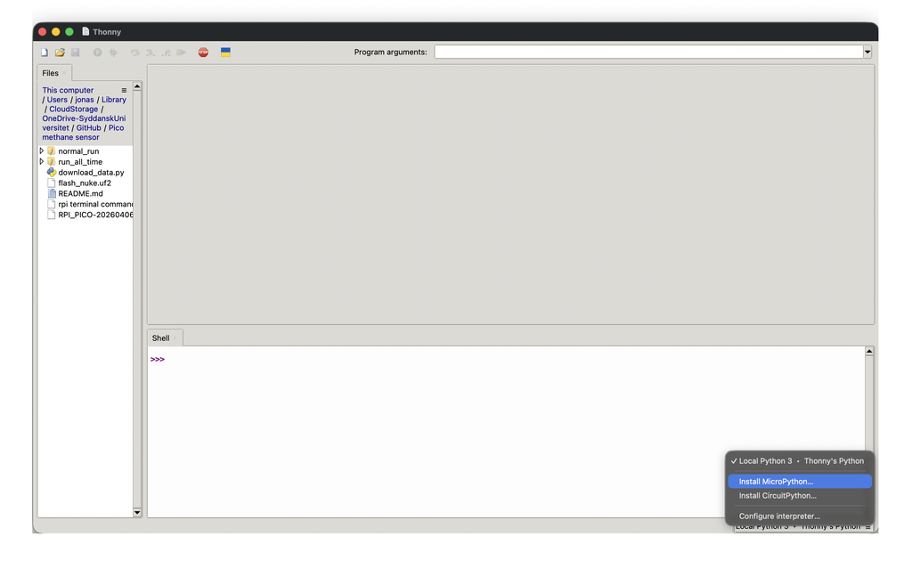

  - Select the options as shown here. Currently the newest version is 1.28.0, but newer versions should also work.

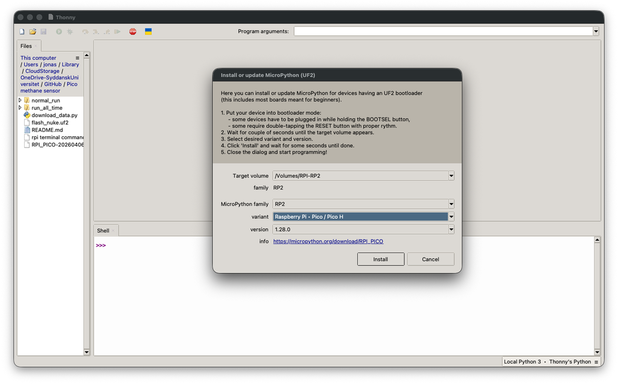

  - Install MicroPython by pressing ‘Install’
4. The sensor will reboot, and you might have to press the ‘Stop’ button at the top to reconnect to it.
5. If you haven’t been using Thonny, now you have to.
6. Ensure that ‘Synchronize device’s real time clock’ is ticked in the settings menu.

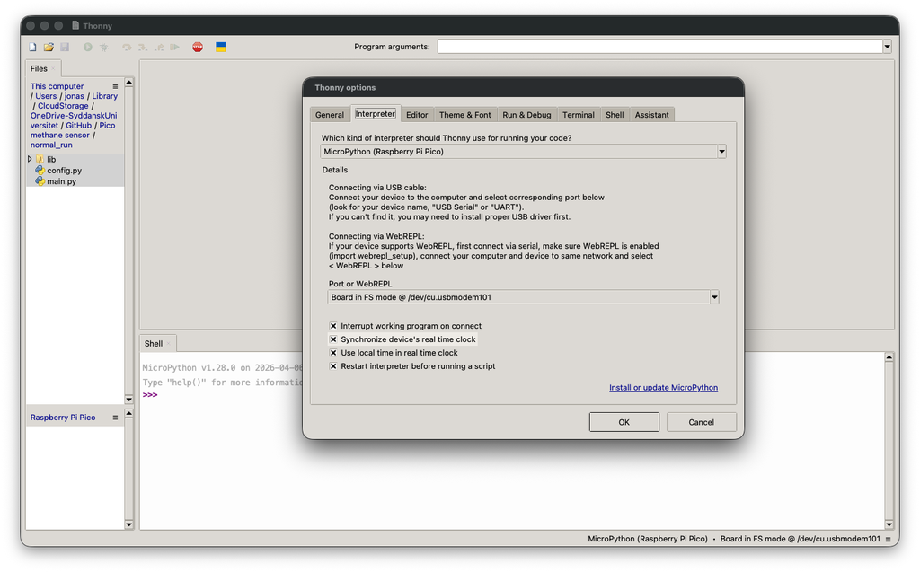

> [!WARNING] All Figaro CH₄ sensors must be calibrated to obtain the correct calibration coefficient. See [(Sø et al., 2024)](https://doi.org/10.1029/2024JG008035) for details.

### Building the chamber

- A 13.5 L bucket with a surface area of 0.0615 m² has been used. Adjust dimensions carefully — the sensor must not contact water.
- Wrap the outside of the bucket in aluminium foil tape to increase reflectance.
- Drill two holes on each side of the bucket at ~¾ of the depth from the top.
- Use two storage boxes (one inside, one outside the bucket). Drill aligned holes through both boxes and the bucket wall. Mount with screws, bolts, and an O-ring to prevent air exchange.
- Drill a small hole for fan wires and seal with silicone.
- Place the fan in the outer storage box and the sensor in the inner box. Connect the fan, observing polarity.
- Cut a 3 cm styrofoam sheet large enough to support the bucket, with a hole in the centre for the bucket. Attach with cable ties through holes drilled at the top of the bucket.
- The 3D-printed pump nozzle (`hardware/3d_prints/pump_nozzle.stl`) connects the air pump outlet to the flexible tubing.

[figure not shown]

## Calibrating the CO<sub>2</sub> sensor

The K33 ELG CO<sub>2</sub> sensor can be calibrated to 400 or 0 ppm by shorting two pins on the sensor. For details, see the [SenseAir K33 ELG product page](https://senseair.com/product/k33-elg/).